# Lab 9 - Multiple Linear Regression

Corinna Hong

Use this template to follow along in Lab Week 9. Each code chunk you’ll need is already created and named.

**Lab 9 Objectives:**

### 1. Load packages

- tidyverse
- stargazer

### 2. Load data (slo_homes.csv) as a df called ‘homes’, then filter to create a data frame called ‘homes_sub’ that only include homes in SLO, Arroyo Grande, Santa Maria-Orcutt, and Atascadero

### 3. Go exploring (visual) + think critically about variables

*Note: It’s OK to LOOK at things separately, even if you’re including all in a model together!*

Example: if we want to compare distribution of housing prices by CITY (ignoring all other variables), we can do that:

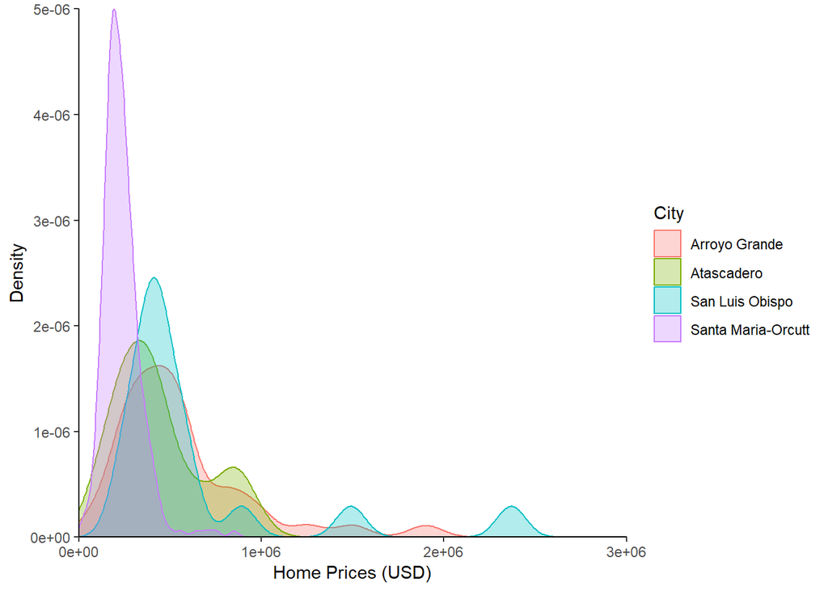

Or another question: Overall relationship between home square footage and price, separated by City?

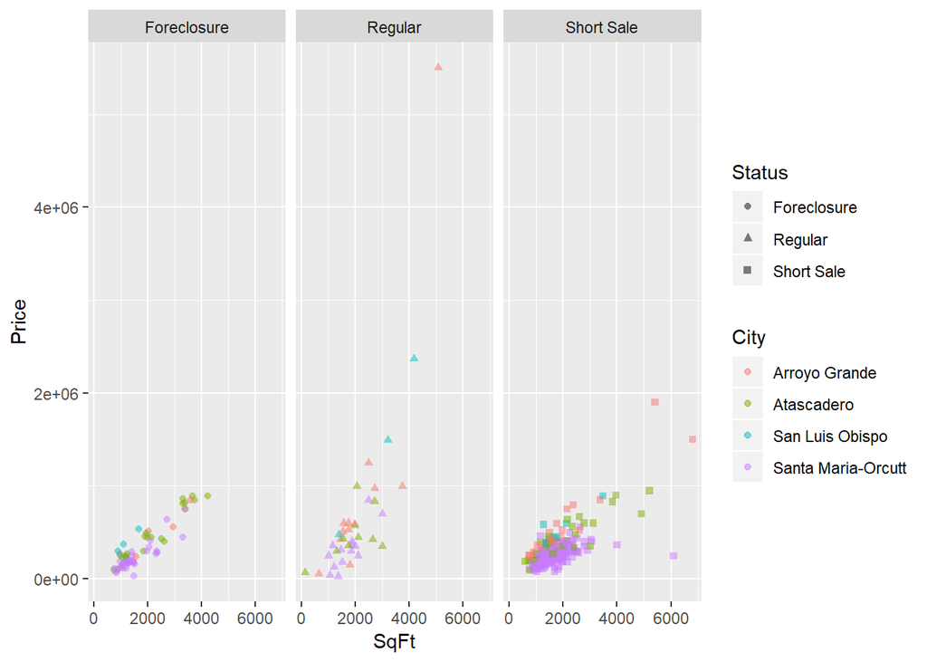

### 4. Multiple linear regression

Multiple linear regression in R follows the same syntax we’ve been using so far:

```
lm(y ~ x1 + x2 + x3..., data = df_name)
```

Let’s try this model a couple of different ways:

1. Use all available variables (saturated model)
2. Use only SqFt as a predictor for “home size” generally (omit Bathrooms and Bedrooms), and omit PricePerSqFt (since it’s derived from two other existing variables in the model)

Use summary() to view the model output and statistics.

```
##
## Call:
## lm(formula = Price ~ City + Bedrooms + Bathrooms + SqFt + PricePerSqFt +
##     Status, data = homes_sub)
##
## Residuals:
##     Min      1Q  Median      3Q     Max
## -965651  -47223    1947   48183 1741280
##
## Coefficients:
##                          Estimate Std. Error t value Pr(>|t|)
## (Intercept)            -626690.88   47272.70 -13.257  < 2e-16 ***
## CityAtascadero           -9068.19   29012.35  -0.313  0.75478
## CitySan Luis Obispo     -76863.04   41030.47  -1.873  0.06177 .
## CitySanta Maria-Orcutt  120160.70   28338.22   4.240 2.79e-05 ***
## Bedrooms                -30792.77   10841.58  -2.840  0.00474 **
## Bathrooms                27998.67   13251.72   2.113  0.03525 *
## SqFt                       230.73      14.31  16.126  < 2e-16 ***
## PricePerSqFt              2962.85     105.54  28.074  < 2e-16 ***
## StatusRegular           -19792.27   29484.61  -0.671  0.50244
## StatusShort Sale        -41575.71   18900.82  -2.200  0.02841 *
## ---
## Signif. codes:  0 '***' 0.001 '**' 0.01 '*' 0.05 '.' 0.1 ' ' 1
##
## Residual standard error: 138800 on 393 degrees of freedom
## Multiple R-squared:  0.8492, Adjusted R-squared:  0.8457
## F-statistic: 245.9 on 9 and 393 DF,  p-value: < 2.2e-16
```

The next model: Exclude price per square foot, and bedrooms/bathrooms (since these are largely explained by square footage…)

```
##
## Call:
## lm(formula = Price ~ City + SqFt + Status, data = homes_sub)
##
## Residuals:
##      Min       1Q   Median       3Q      Max
## -1087480   -68268     8241    62660  3938242
##
## Coefficients:
##                          Estimate Std. Error t value Pr(>|t|)
## (Intercept)             106333.12   57574.57   1.847   0.0655 .
## CityAtascadero         -202157.51   49077.01  -4.119 4.63e-05 ***
## CitySan Luis Obispo      34525.41   70837.96   0.487   0.6263
## CitySanta Maria-Orcutt -275841.28   42992.76  -6.416 4.00e-10 ***
## SqFt                       245.93      15.33  16.048  < 2e-16 ***
## StatusRegular           209998.86   49636.98   4.231 2.90e-05 ***
## StatusShort Sale          2282.42   32894.07   0.069   0.9447
## ---
## Signif. codes:  0 '***' 0.001 '**' 0.01 '*' 0.05 '.' 0.1 ' ' 1
##
## Residual standard error: 243100 on 396 degrees of freedom
## Multiple R-squared:  0.5339, Adjusted R-squared:  0.5268
## F-statistic:  75.6 on 6 and 396 DF,  p-value: < 2.2e-16
```

Wait…but what if I wanted everything to be with respect to a Regular sale status? Then I need to change my factor levels. We’ve done this before, here we’ll use a different function (fct_relevel) from *forcats* package in the tidyverse.

Interpret the coefficients and statistical outcomes above. Notes:

### 5. Model diagnostics

Remember, since we’re concerned about *residuals* (distance that actual observations exist from model predictions), we can only evaluate some assumptions *after* running the regression.

Then we can evaluate model diagnostics using the plot() function:

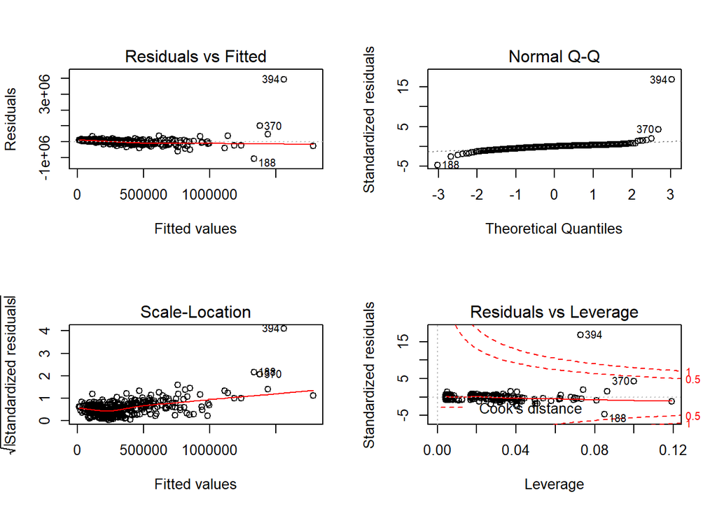

### 7. Regression tables with *stargazer*

|  | *Dependent variable:* |  |
| --- | --- | --- |
|  | Price |  |
|  | (1) | (2) |
| CityAtascadero | -9,068.194 | -202,157.500*** |
|  | (29,012.350) | (49,077.010) |
| CitySan Luis Obispo | -76,863.040* | 34,525.410 |
|  | (41,030.470) | (70,837.960) |
| CitySanta Maria-Orcutt | 120,160.700*** | -275,841.300*** |
|  | (28,338.220) | (42,992.760) |
| Bedrooms | -30,792.770*** |  |
|  | (10,841.580) |  |
| Bathrooms | 27,998.670** |  |
|  | (13,251.720) |  |
| SqFt | 230.726*** | 245.934*** |
|  | (14.308) | (15.325) |
| PricePerSqFt | 2,962.850*** |  |
|  | (105.537) |  |
| StatusRegular | -19,792.270 |  |
|  | (29,484.610) |  |
| StatusForeclosure |  | -209,998.900*** |
|  |  | (49,636.970) |
| StatusShort Sale | -41,575.710** | -207,716.400*** |
|  | (18,900.820) | (43,222.290) |
| Constant | -626,690.900*** | 316,332.000*** |
|  | (47,272.690) | (59,022.440) |
| Observations | 403 | 403 |
| R<sup>2</sup> | 0.849 | 0.534 |
| Adjusted R<sup>2</sup> | 0.846 | 0.527 |
| Residual Std. Error | 138,805.900 (df = 393) | 243,102.100 (df = 396) |
| F Statistic | 245.896*** (df = 9; 393) | 75.603*** (df = 6; 396) |
| *Note:* | p<0.1; p<0.05; p<0.01 |  |

### 8. Making predictions

Using your final selected model, predict the housing price for a range of home sizes, sale status, and city.

The predict() function uses the following syntax:

```
  predict(model_name, newdata = new_data_name)
```

Defaults are to exclude the prediction SE and mean confidence interval - if you want to include, use arguments

```
  se.fit = TRUE
  interval = "confidence"
  interval = "prediction"
```

First, you need to create a new data frame of values that contain ALL NECESSARY VARIABLES **with the same variable names AND level strings**.

Make predictions for the new data using predict():

Then visualize it!

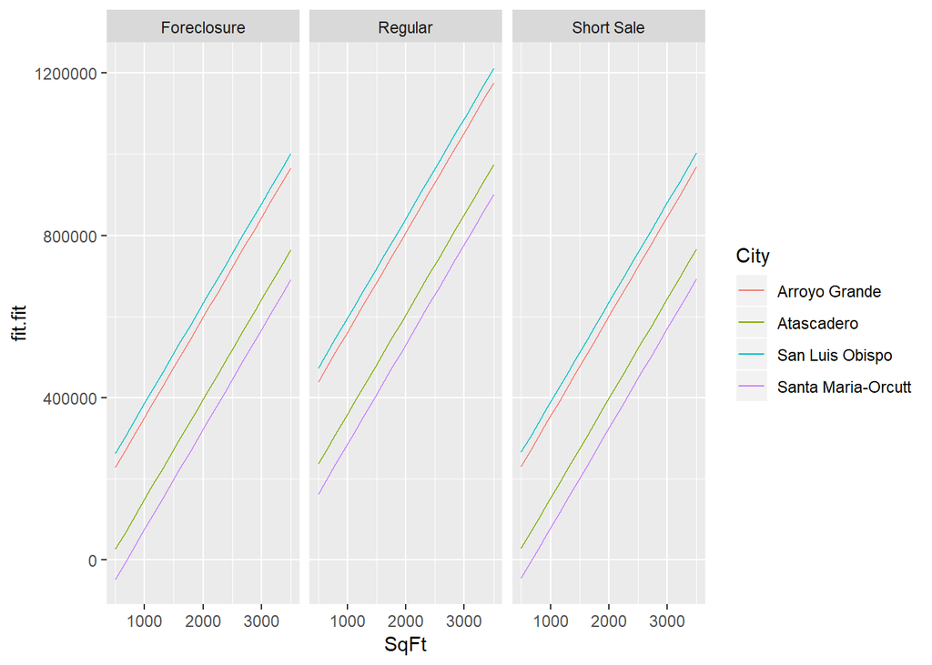

END LAB